# Lab_8

Yehudis

5/1/2021

1. Consider a 2x2 design. Assume the DV is measured from a normal distribution with mean 0, and standard deviation 1. Assume that the main effect of A causes a total shift of .5 standard deviations of the mean between the levels. Assume that level 1 of B is a control, where you expect to measure the standard effect of A. Assume that level 2 of B is an experimental factor intended to reduce the effect of A by .25 standard deviations.

A. create a ggplot2 figure that depicts the expected results from this design (2 points)

```r
library(tibble)
library(ggplot2)
library(patchwork)
# define 2-factor score model
grand_mean <- 10
A <- c(-5,0,5)
B <- c(-5,0,5)
AB <- rep(0,length(A)*length(B))

# create design table
model_data <- tibble()
for(i in 1:length(A)){
  for(j in 1:length(B)){
    IVA <- i
    IVB <- j
    DV <- grand_mean+A[i]+B[j]+AB[(i-1)*length(B)+j]
    sc_GM <- grand_mean
    sc_A <- A[i]
    sc_B <- B[j]
    sc_AB <- AB[(i-1)*length(B)+j]
    row_entry <- tibble(IVA,IVB,DV,
                        sc_GM,sc_A,sc_B,sc_AB)
    model_data <- rbind(model_data,row_entry)
  }
}

knitr::kable(model_data)
```

| IVA | IVB | DV | sc_GM | sc_A | sc_B | sc_AB |
| --- | --- | --- | --- | --- | --- | --- |
| 1 | 1 | 0 | 10 | -5 | -5 | 0 |
| 1 | 2 | 5 | 10 | -5 | 0 | 0 |
| 1 | 3 | 10 | 10 | -5 | 5 | 0 |
| 2 | 1 | 5 | 10 | 0 | -5 | 0 |
| 2 | 2 | 10 | 10 | 0 | 0 | 0 |
| 2 | 3 | 15 | 10 | 0 | 5 | 0 |
| 3 | 1 | 10 | 10 | 5 | -5 | 0 |
| 3 | 2 | 15 | 10 | 5 | 0 | 0 |
| 3 | 3 | 20 | 10 | 5 | 5 | 0 |

[figure not shown]

```r
# generate plots
bar_graph <- ggplot(model_data,
                    aes(y=DV,
                        x=as.factor(IVA),
                        fill=as.factor(IVB)))+
  geom_bar(stat='identity', position='dodge')

line_graph <- ggplot(model_data,
                     aes(y=DV,
                         x=IVA,
                         linetype=as.factor(IVB)))+
  geom_line()+
  geom_point()

(bar_graph/line_graph)
```

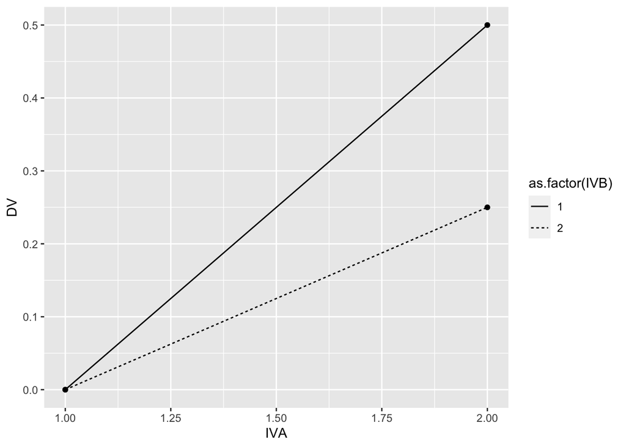

```r
#alternative

model_data <- tibble(IVA=c(1,1,2,2),
                     IVB=c(1,2,1,2),
                     DV=c(0,0,.5,.25))

ggplot(model_data,
                     aes(y=DV,
                         x=IVA,
                         linetype=as.factor(IVB)))+
  geom_line()+
  geom_point()
```

Conduct simulation-based power analyses to answer the questions.

B. How many subjects are needed to detect the main effect of A with power = .8? (2 points)

```r
# N per group
N <- 57

A_pvalue <- c()
B_pvalue <- c()
AB_pvalue <- c()
for(i in 1:1000){
  IVA <- rep(rep(c("1","2"), each=2),N)
  IVB <- rep(rep(c("1","2"), 2),N)
  DV <- c(replicate(N,c(rnorm(1,0,1), # means A1B1
                        rnorm(1,0,1), # means A1B2
                        rnorm(1,.5,1), # means A2B1
                        rnorm(1,.25,1)  # means A2B2
          )))
  sim_df <- data.frame(IVA,IVB,DV)

  aov_results <- summary(aov(DV~IVA*IVB, sim_df))
  A_pvalue[i]<-aov_results[[1]]$`Pr(>F)`[1]
  B_pvalue[i]<-aov_results[[1]]$`Pr(>F)`[2]
  AB_pvalue[i]<-aov_results[[1]]$`Pr(>F)`[3]
}

length(A_pvalue[A_pvalue<0.05])/1000
```

```
## [1] 0.818
```

```r
length(B_pvalue[B_pvalue<0.05])/1000
```

```
## [1] 0.134
```

```r
length(AB_pvalue[AB_pvalue<0.05])/1000
```

```
## [1] 0.153
```

```r
#alt

N <- 57

A_pvalue <- c()
B_pvalue <- c()
AB_pvalue <- c()
for(i in 1:1000){
  IVA <- rep(rep(c("1","2"), each=2),N)
  IVB <- rep(rep(c("1","2"), 2),N)
  DV <- c(replicate(N,c(rnorm(1,0,1), # means A1B1
                        rnorm(1,0,1), # means A1B2
                        rnorm(1,.5,1), # means A2B1
                        rnorm(1,.25,1)  # means A2B2
          )))
  sim_df <- data.frame(IVA,IVB,DV)
  aov_results <- summary(aov(DV~IVA*IVB, sim_df))
  A_pvalue[i]<-aov_results[[1]]$`Pr(>F)`[1]
  B_pvalue[i]<-aov_results[[1]]$`Pr(>F)`[2]
  AB_pvalue[i]<-aov_results[[1]]$`Pr(>F)`[3]
}

length(A_pvalue[A_pvalue<0.05])/1000
```

```
## [1] 0.801
```

```r
length(B_pvalue[B_pvalue<0.05])/1000
```

```
## [1] 0.158
```

```r
length(AB_pvalue[AB_pvalue<0.05])/1000
```

```
## [1] 0.144
```

```r
rnorm(4*N,c(0,0,.5,.25),.001)
```

[output not shown]

[output cut: 31 more lines]

C. How many subjects are needed to detect the interaction effect with power = .8? (2 points)

```r
N <- 500


AB_pvalue <- c()

for(i in 1:1000){

  sim_df <- tibble(
  IVA <- rep(rep(c("1","2"), each=2),N),
  IVB <- rep(rep(c("1","2"), 2),N),
  DV <- rnorm(4*N,c(0,0,.5,.25),1)
  )

  aov_results <- summary(aov(DV~IVA*IVB, sim_df))
  AB_pvalue[i]<-aov_results[[1]]$`Pr(>F)`[3]
}

length(AB_pvalue[AB_pvalue<0.05])/1000
```

[output not shown]

Bonus point question:

B1. Create a power curve showing how power for the interaction effect in this example is influenced by number of subjects. Choose a range of N from 25 to 800 (per cell) and run a simulation-based power analysis for increments of 25 subjects. Then plot the results using ggplot2 (2 points).

[figure not shown]

```r
subject_increments <- seq(25,800,25)
power_estimate <- c()

for(si in 1:length(subject_increments)) {

N <- subject_increments[si]

AB_pvalue <- c()

for(i in 1:1000){

  sim_df <- tibble(
  IVA <- rep(rep(c("1","2"), each=2),N),
  IVB <- rep(rep(c("1","2"), 2),N),
  DV <- rnorm(4*N,c(0,0,.5,.25),1)
  )

  aov_results <- summary(aov(DV~IVA*IVB, sim_df))
  AB_pvalue[i]<-aov_results[[1]]$`Pr(>F)`[3]
}

power_estimate[si] <- length(AB_pvalue[AB_pvalue<0.05])/1000

}

power_curve <- tibble(subject_increments,
                      power_estimate)

ggplot(power_curve, aes(x=subject_increments,
                        y=power_estimate))+
  geom_point()+
  geom_line()+
  scale_x_continuous(breaks=subject_increments)+
  theme_classic(base_size=9)
```